# Visualization_part_2

Анастасия Потамошнева

```r
theme_custom <- theme(
    panel.background = element_rect(fill = "white"),
    plot.title = element_text(size = 30, hjust = 0.5),
    plot.subtitle = element_text(size = 25, hjust = 0.5),
    strip.text = element_text(size = 20),
    axis.text = element_text(size = 20),
    axis.title = element_text(size = 25),
    legend.title = element_text(size = 25),
    legend.text = element_text(size = 20)
  )
```

## Скаттерплоты

### Задание 1

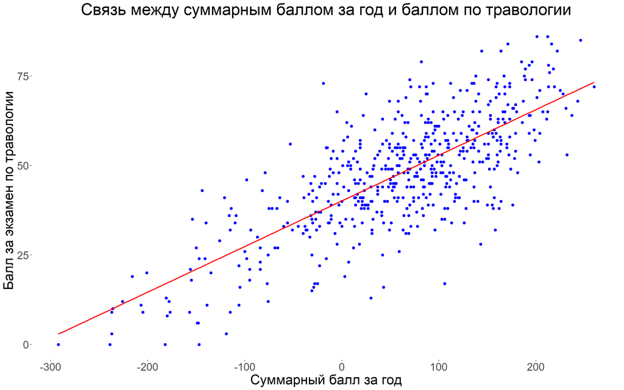

```r
ggplot(hogwarts, aes(x = result, y = `Herbology exam`)) +
  geom_point(size = 1,
             stroke = 1.5,
             color = "blue") +
  geom_smooth(method = "lm", se = FALSE, color = "red", linewidth=1) +
  labs(title = "Связь между суммарным баллом за год и баллом по травологии",
       x = "Суммарный балл за год",
       y = "Балл за экзамен по травологии") +
  theme_custom
```

Интерпретация: студенты с более высоким суммарным баллом за год обычно имели более высокий балл по травологии. При этом данные имеют большой разброс (некоторые студенты имели высокий годовой балл и низкий по травологии или наоборот).

### Задание 2

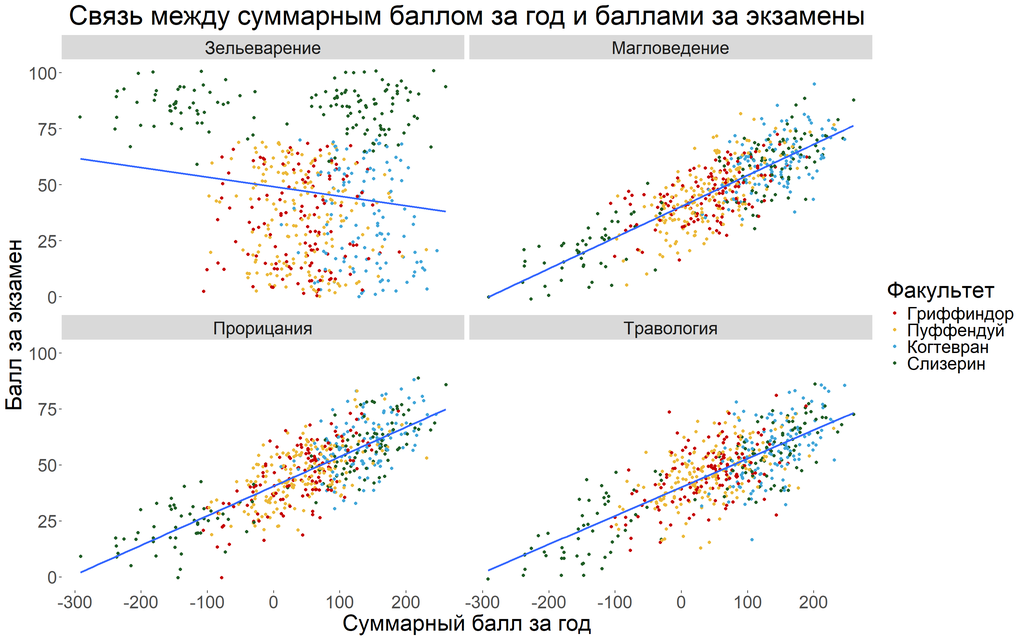

```r
exams <- hogwarts %>%
  rename_with(function(x) x %>%
                str_replace("Divinations exam", "Прорицания") %>%
                str_replace("Herbology exam", "Травология") %>%
                str_replace("Muggle studies exam", "Магловедение") %>%
                str_replace("Potions exam", "Зельеварение")) %>%
  pivot_longer(cols = c(`Травология`, `Магловедение`, `Прорицания`, `Зельеварение`),
               names_to = "exam", values_to = "score")

ggplot(exams, aes(x = result, y = score)) +
  geom_point(aes(color=house),
             position = position_jitter(width = 1, height = 1)) +
  geom_smooth(method = "lm", se = FALSE) +
  facet_wrap(~exam) +
  scale_color_manual(values = c("Gryffindor" = "#C50000",
                             "Hufflepuff" = "#ECB939",
                             "Ravenclaw" = "#41A6D9",
                             "Slytherin" = "#1F5D25"),
                     labels= c("Hufflepuff"="Пуффендуй",
                            "Slytherin" = "Слизерин",
                            "Gryffindor" = "Гриффиндор",
                            "Ravenclaw" = "Когтевран" ))+
  labs(title = "Связь между суммарным баллом за год и баллами за экзамены",
       x = "Суммарный балл за год",
       y = "Балл за экзамен",
       color = "Факультет") +
  theme_custom
```

Интерпретация: студенты, получившие высокий балл за год, обычно получали высокий балл по прорицаниям, магловедению или травологии, на зельеварении-наоборот. Высокие баллы выше 75 по зельеварению получали только студенты Слизерина, и никто из Слизерина не получил балл меньше 50. На остальных же предметах ученики Слизерина обычно набирали баллы ниже студентов остальных факультетов, они же преимущественно теряли баллы за год. Наиболее высокие отметки за прорицания, магловедение и травологию, а также суммарные балл за год, преимущественно получали студенты Когтеврана.

### Задание 3

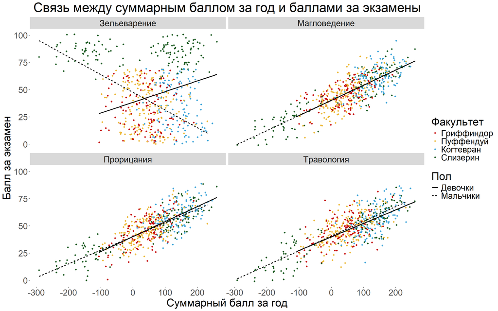

```r
ggplot(exams, aes(x = result, y = score)) +
  geom_point(aes(color=house),
             position = position_jitter(width = 1, height = 1)) +
  geom_smooth(aes(linetype=sex), color="black",method = "lm", se = FALSE) +
  facet_wrap(~exam) +
  scale_color_manual(values = c("Gryffindor" = "#C50000",
                             "Hufflepuff" = "#ECB939",
                             "Ravenclaw" = "#41A6D9",
                             "Slytherin" = "#1F5D25"),
                     labels= c("Hufflepuff"="Пуффендуй",
                            "Slytherin" = "Слизерин",
                            "Gryffindor" = "Гриффиндор",
                            "Ravenclaw" = "Когтевран")) +
  scale_linetype_discrete(labels = c("female" = "Девочки",
                            "male" = "Мальчики"))+
  labs(title = "Связь между суммарным баллом за год и баллами за экзамены",
       x = "Суммарный балл за год",
       y = "Балл за экзамен",
       color = "Факультет",
       linetype ="Пол") +
  theme_custom
```

## Geom_col

### Задание 1

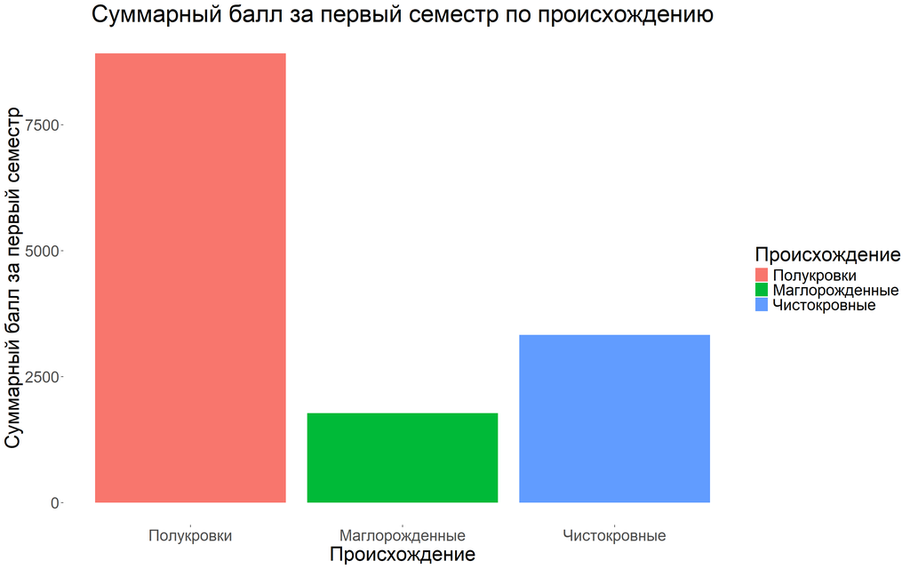

```r
hogwarts %>%
  rowwise() %>%
  mutate(semester_score = sum(c_across(week_1:week_17), na.rm = TRUE)) %>%
  ungroup() %>%
  group_by(bloodStatus) %>%
  summarise(semester_score = sum(semester_score, na.rm = TRUE)) %>%
ggplot(aes(x = bloodStatus, y = semester_score, fill = bloodStatus)) +
  geom_col() +
  scale_fill_discrete(labels=c("half-blood"="Полукровки",
                               "muggle-born"="Маглорожденные",
                               "pure-blood"="Чистокровные"))+
  scale_x_discrete(labels=c("half-blood"="Полукровки",
                               "muggle-born"="Маглорожденные",
                               "pure-blood"="Чистокровные"))+
  labs(title = "Суммарный балл за первый семестр по происхождению",
       x = "Происхождение",
       y = "Суммарный балл за первый семестр",
       fill = "Происхождение")+
  theme_custom
```

Гипотеза: самый высокий суммарный балл за первый семестр у полукровок, а самый низкий - у маглов, так как их соответственно большинство и меньшинство среди студентов.

### Задание 2

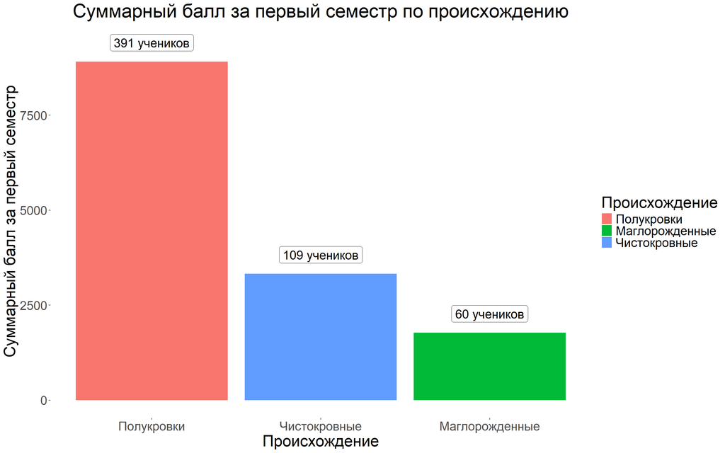

```r
hogwarts %>%
  rowwise() %>%
  mutate(semester_score = sum(c_across(week_1:week_17), na.rm = TRUE)) %>%
  ungroup() %>%
  group_by(bloodStatus) %>%
  summarise(semester_score = sum(semester_score, na.rm = TRUE), count=n()) %>%
ggplot(aes(x = fct_reorder(bloodStatus, semester_score, .desc=TRUE), y = semester_score, fill = bloodStatus)) +
  geom_col() +
  scale_fill_discrete(labels=c("half-blood"="Полукровки",
                               "muggle-born"="Маглорожденные",
                               "pure-blood"="Чистокровные"))+
  scale_x_discrete(labels=c("half-blood"="Полукровки",
                               "muggle-born"="Маглорожденные",
                               "pure-blood"="Чистокровные"))+
  labs(title = "Суммарный балл за первый семестр по происхождению",
       x = "Происхождение",
       y = "Суммарный балл за первый семестр",
       fill = "Происхождение") +
  geom_label(aes(label= paste0(count, " учеников")),
             nudge_y=500,
             size=7,
             fill="white")+ #Можно ли поменять название только в первом столбике для согласования падежей? "Ученик" вместо "учеников"
  theme_custom
```

Интерпретация: студентов-полукровок примерно в 6,5 раз больше, чем маглов, а чистокровных-примерно в 2 раза, что и объясняет разницу в суммарном балле.

### Задание 3

```r
hogwarts %>%
  rowwise() %>%
  mutate(semester_score = sum(c_across(week_1:week_17), na.rm = TRUE)) %>%
  ungroup() %>%
  group_by(bloodStatus, sex) %>%
  mutate(sex = case_when(
    sex == "male" ~ "Мальчики",
    sex == "female" ~ "Девочки"
  )) %>%
  summarise(semester_score = sum(semester_score, na.rm = TRUE), count=n()) %>%
ggplot(aes(x = fct_reorder(bloodStatus, semester_score, .desc=TRUE),
           y = semester_score,
           fill = bloodStatus)) + #Как сделать сортировку по убыванию в каждом фасете?
  geom_col() +
  facet_wrap(~sex, ncol=1)+
  scale_fill_discrete(labels=c("half-blood"="Полукровки",
                               "muggle-born"="Маглорожденные",
                               "pure-blood"="Чистокровные"))+
  scale_x_discrete(labels=c("half-blood"="Полукровки",
                               "muggle-born"="Маглорожденные",
                               "pure-blood"="Чистокровные"))+
  labs(title = "Суммарный балл за первый семестр по происхождению",
       x = "Происхождение",
       y = "Суммарный балл за первый семестр",
       fill = "Происхождение")+
  scale_y_continuous(breaks = seq(-500,10000,1000))+
  geom_label(aes(label= paste0(count, " уч.")), nudge_y=500, size=6, fill="white")+
  coord_flip()+
  theme_custom+
  theme(legend.position = "bottom",
        legend.justification = "right") -> ScoreByBloodStatusandSex

ggsave("ScoreByBloodStatusandSex.png",ScoreByBloodStatusandSex, width = 20, height = 15, dpi = 300, units = "in")
```

### Задание 4

Coord_flip полезен,когда есть уже готовый график, где нужно поменять оси, при этом плюсом является то, что не нужно вручную менять местами оси и их параметры, а также она не влияет на порядок фасетирования.

Минусы: нужна донастройка отдельных элементов (например, как в nudge_y выше).

## Разное

### Задание 1

```r
# График 1 - боксплот
boxplot_1 <- hogwarts %>%
  rename_with(function(x) x %>%
                str_replace("Potions exam", "Зельеварение") %>%
                str_replace("Study of ancient runes exam", "Древние руны")) %>%
  select(id, `Зельеварение`, `Древние руны`) %>%
  pivot_longer(!id,
               names_to = "exam",
               values_to = "score") %>%
  ggplot(aes(x = exam,
                   y = score, fill=exam))+
  geom_boxplot(color="black", notch=TRUE, outliers=FALSE)+
  geom_jitter()+
  scale_fill_manual(values = c("Зельеварение"= "darkgreen",
                              "Древние руны"= "burlywood3"))+
  labs(x = "Экзамен",
       y = "Балл",
       fill="Экзамен")+
  theme_custom+
  theme(legend.position = "none")
```

```r
# График 2- violin plot

violinplot_1 <- hogwarts %>%
  rename_with(function(x) x %>%
                str_replace("Potions exam", "Зельеварение") %>%
                str_replace("Study of ancient runes exam", "Древние руны")) %>%
  select(id, `Зельеварение`, `Древние руны`) %>%
  pivot_longer(!id,
               names_to = "exam",
               values_to = "score") %>%
  ggplot(aes(x = exam,
                   y = score, fill=exam))+
  geom_violin(color="black", notch=TRUE, outliers=FALSE)+
  geom_boxplot(width=0.1)+
  scale_fill_manual(values = c("Зельеварение"= "darkgreen",
                              "Древние руны"= "burlywood3"))+
  labs(x = "Экзамен",
       y = "Балл",
       fill="Экзамен")+
  theme_custom+
  theme(legend.position = "none")
```

```r
# График 3- density plot

densityplot_1 <- ggplot(hogwarts)+
  geom_density(aes(x = `Potions exam`, fill = "Зельеварение"), alpha = 0.7) +
  geom_density(aes(x = `Study of ancient runes exam`, fill = "Древние руны"), alpha = 0.5)+
  scale_fill_manual(values = c("Зельеварение"= "darkgreen",
                              "Древние руны"= "burlywood3"))+
  labs(title = "Распределение баллов по зельеварению и древним рунам",
       x = "Балл",
       y = "Плотность вероятности",
       fill="Экзамен")+
  theme_custom+
  theme(legend.position = "bottom",
        legend.justification = "left")
```

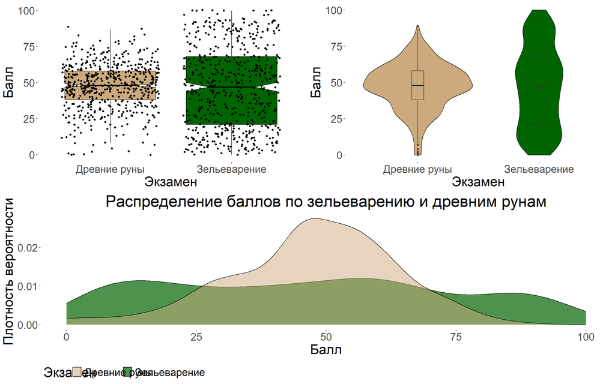

```r
combined_1 <- ggarrange(plotlist=list(boxplot_1, violinplot_1), ncol=2, nrow=1, widths=c(1,1))
ggarrange(plotlist=list(combined_1, densityplot_1), ncol=1, nrow=2) #Почему возникает слипание легенды на нижнем графике?
```

## Задание 2

```r
hogwarts %>%
  group_by(bloodStatus) %>%
  summarise(meanPotionsExam = mean(`Potions exam`) %>% round(2),
            Min = (min(`Potions exam`) %>% round(2)),
            Max = (max(`Potions exam`) %>% round(2))) %>%
  ggplot(aes(x = fct_relevel(bloodStatus, "muggle-born", "pure-blood", "half-blood") ,
               y = meanPotionsExam)) +
  geom_pointrange(aes(ymin = Min,
                      ymax = Max,
                    colour = bloodStatus),
                linewidth = 2,
                fatten = 7) +
  ylim(0, 100) +
  scale_color_discrete(labels=c("pure-blood" = "Чистокровные",
               "half-blood"= "Полукровки",
               "muggle-born" = "Маглорожденные"))+
  labs(title = "Средний балл по зельеварению",
       x = "Происхождение",
       y = "Балл",
       color="Происхождение") +
  theme_custom+
  theme(legend.position = "bottom",
        legend.justification = "left") -> meanPotions
```

Интерпретация: студенты всех происхождений набирали одинаково низкие минимальные и одинаково высокие максимальные баллы по зельеварению, но средний балл маглов был ниже, чем у учеников других происхождений.

Гипотеза: на самом деле маглы имеют самый низкий средний балл, так как большинство из них не в Слизерине, а студенты других факультетов получают в целом ниже баллы.

```r
hogwarts %>%
  group_by(bloodStatus, house) %>%
  summarise(meanPotionsExam = mean(`Potions exam`) %>% round(2),
            Min = (min(`Potions exam`) %>% round(2)),
            Max = (max(`Potions exam`) %>% round(2)),
  count = n()) %>%
  ggplot(aes(x = bloodStatus,
               y = meanPotionsExam)) +
  geom_pointrange(aes(ymin = Min,
                      ymax = Max,
                    colour = bloodStatus),
                linewidth = 2,
                fatten = 7) +
   facet_wrap(~house)+
  geom_text(aes(label = count,
                x = bloodStatus,
                y = Max),
            nudge_x = 0.2,
            size = 7) +
  ylim(0, 100) +
  scale_color_discrete(labels=c("pure-blood" = "Чистокровные",
               "half-blood"= "Полукровки",
               "muggle-born" = "Маглорожденные"))+
  labs(title = "Средний балл по зельеварению",
       x = "Происхождение",
       y = "Балл",
       color="Происхождение") +
  theme_custom+
  theme(legend.position = "bottom",
        legend.justification = "left") -> mugglesByHouse
```

Интерпретация: студенты-маглы из Слизерина получают такие же средние баллы, как и другие студенты Слизерина, но их всего 8 человек на факультете. На других факультетах маглы получают примерно одинаковые или чуть ниже баллы по сравнению со студентами своего факультета, но количество маглов на этих факультетах выше. Можно предположить, что низкий общий средний балл обусловлен именно этим.

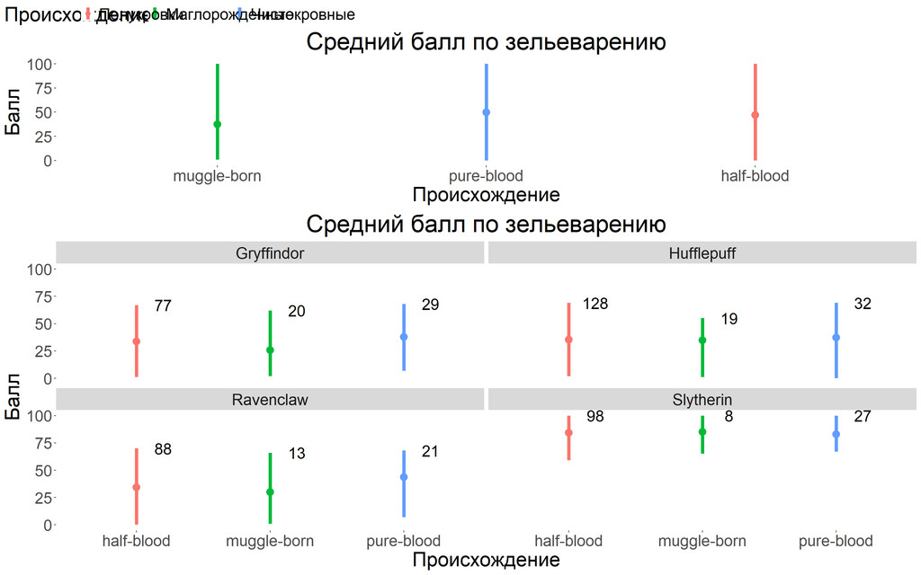

```r
ggarrange(plotlist=list(meanPotions, mugglesByHouse), nrow=2, heights=c(1,2), common.legend=TRUE)
```

## Дополнительно

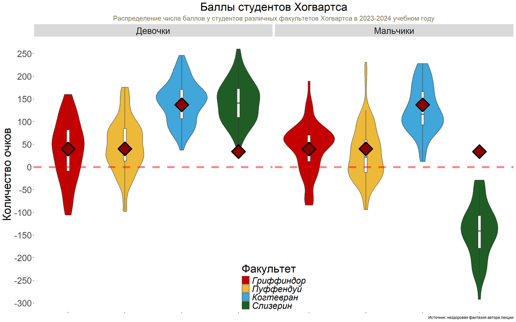

```r
mean_by_house <- hogwarts %>%
  group_by(house) %>%
  summarise(mean=mean(result))

 hogwarts %>% mutate(sex = case_when(
    sex == "male" ~ "Мальчики",
    sex == "female" ~ "Девочки"
  )) %>%

ggplot() +
  geom_violin(aes(x = house, y = result, fill = house)) +
  geom_boxplot(aes(x = house, y = result),fill = "white", width = 0.05, outliers=FALSE) +
  geom_point(data=mean_by_house, aes(x = house, y = mean),
             shape = 23, size = 10, color = "black", fill = "darkred", stroke=2) +
  geom_hline(yintercept = 0, color = "red", linetype = "dashed", size = 2, alpha=0.5) +
  facet_wrap(~sex, ncol = 2) +
  scale_fill_manual(values = c("Gryffindor" = "#C50000",
                               "Hufflepuff" = "#ECB939",
                               "Ravenclaw" = "#41A6D9",
                               "Slytherin" = "#1F5D25"),
                    labels= c("Hufflepuff"="Пуффендуй",
                            "Slytherin" = "Слизерин",
                            "Gryffindor" = "Гриффиндор",
                            "Ravenclaw" = "Когтевран")) +
  labs(title = "Баллы студентов Хогвартса",
       subtitle = "Распределение числа баллов у студентов различных факультетов Хогвартса в 2023-2024 учебном году",
       y = "Количество очков",
       caption = "Источник: нездоровая фантазия автора лекции",
       fill = "Факультет") +
  scale_y_continuous(breaks = seq(-300,250,50))+
  theme(
    panel.background = element_rect(fill = "white"),
    plot.title = element_text(size = 25, hjust = 0.5),
    plot.subtitle = element_text(size = 15, hjust = 0.5, color="navajowhite4"),
    strip.text = element_text(size = 20),
    axis.text = element_text(size = 20),
    axis.title = element_text(size = 25),
    legend.title = element_text(size = 25),
    legend.text = element_text(size = 20, face="italic"),
    axis.title.x = element_blank(),
    axis.text.x = element_blank(),
    legend.position = "inside",
    legend.justification = c("center", "bottom"))
```